# Praca Domowa 7

Aleksandra Wichrowska

10 czerwca 2019

## Wstęp

W tym zadaniu domowym dokonam analizy i porównania dwóch algorytmów klasteryzacyjnych - k-średnich oraz k-medoidów. Testy będę przeprowadzała na powszechnie znanym zbiorze danych `iris`.

Wykorzystam funkcje zaimplementowane w R:

- `kmeans` z pakietu `stats`
- `pam` pakieru `cluster`

## Wybór liczby klastrów

Optymalną liczbę klastrów wybierzemy na podstawie metod omówionych podczas zajęć:

- silhouette method
- elbow plot
- gap statistic

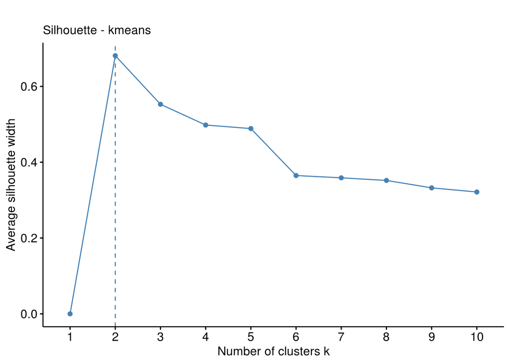

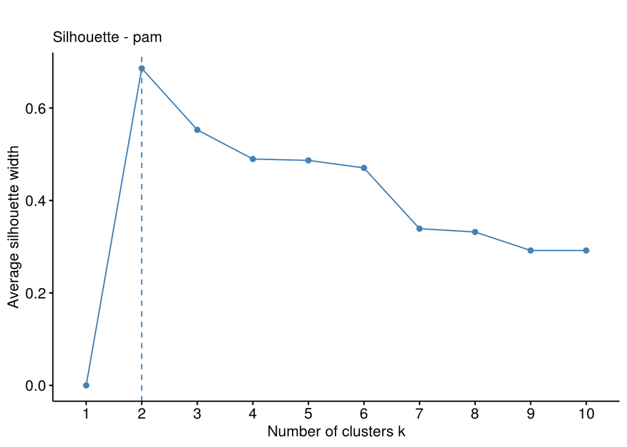

Optymalna liczba klastrów, to ta która maksymalizuje współczynnik `silhouette`, czyli zarówno dla algorytmu k-średnich, jak i k-medoidów to dwa klastry.

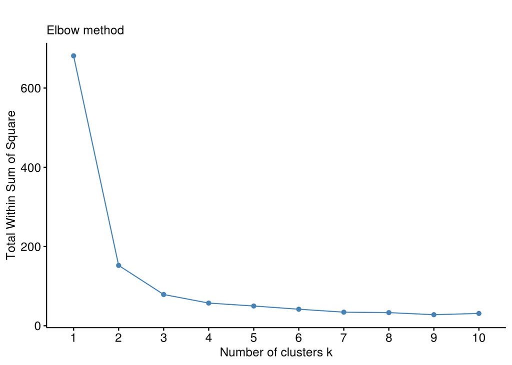

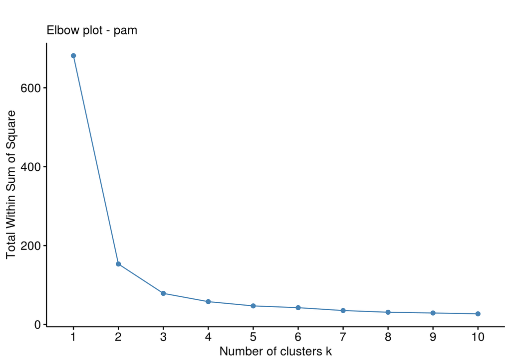

Z `elbow plot` dla obu algorytmu odczytujemy optymalną liczbę klastru jako 2 lub 3.

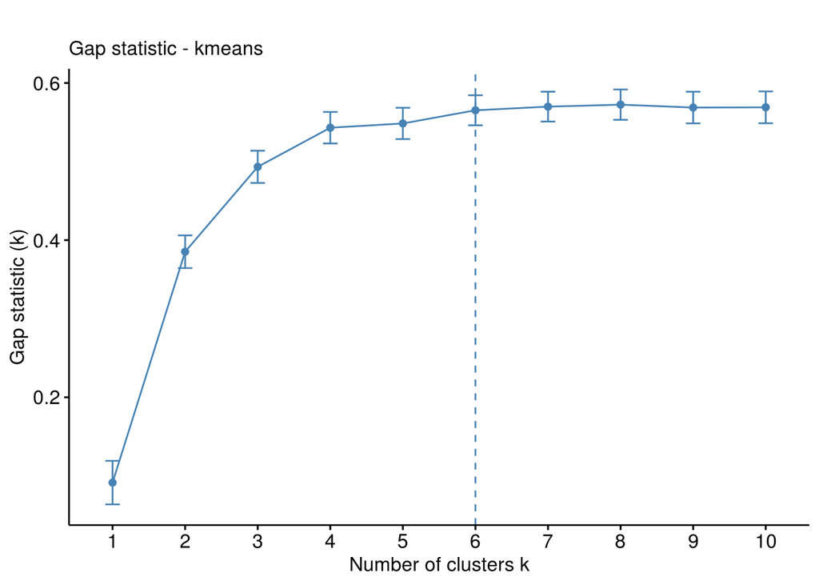

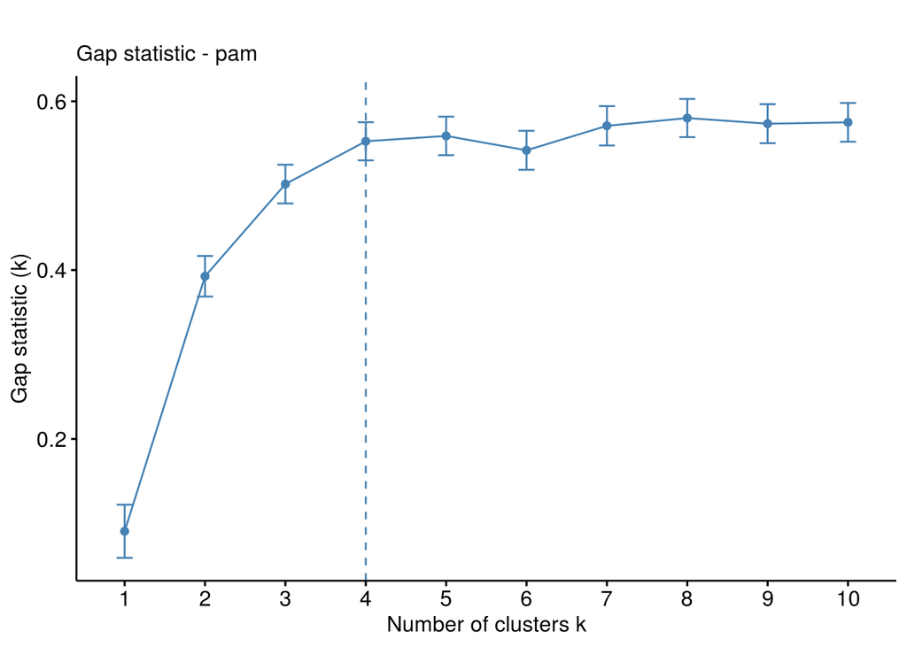

Z `gap statistic` wynika, że optymalna liczba klastrów dla algorytmu k-średnich to 6, a dla k-medoidów 4.

# Klasteryzacja

W dalszych rozważaniach będziemy przeprowadzać testy dla 2 i 3 klastrów.

## Dla dwóch klastrów

### Algorytm k-średnich

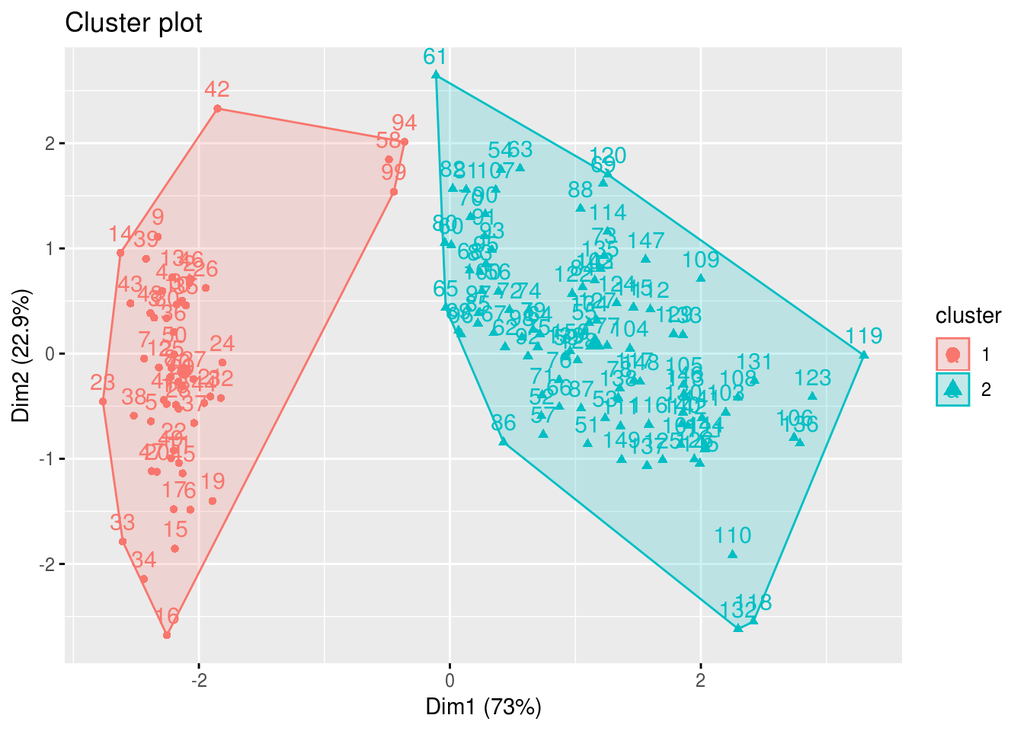

### Algorytm k-medoidów

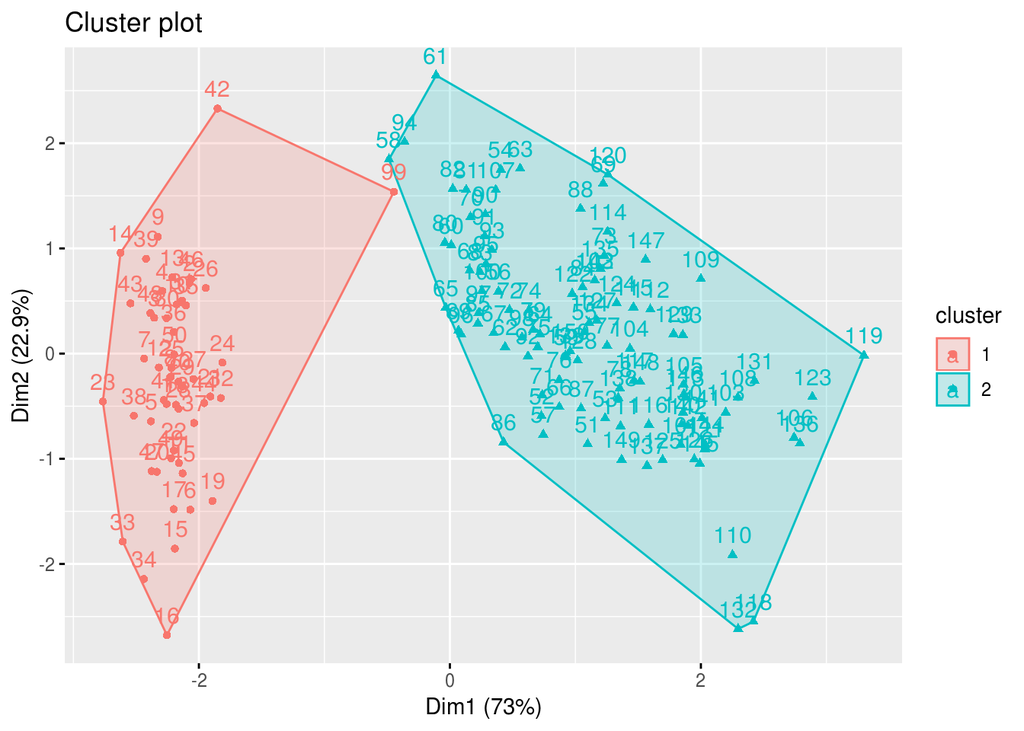

## Dla trzech klastrów

### Algorytm k-średnich

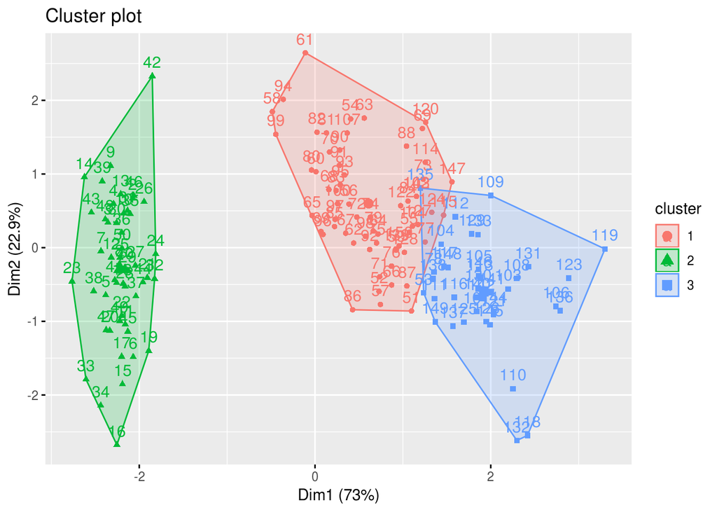

### Algorytm k-medoidów

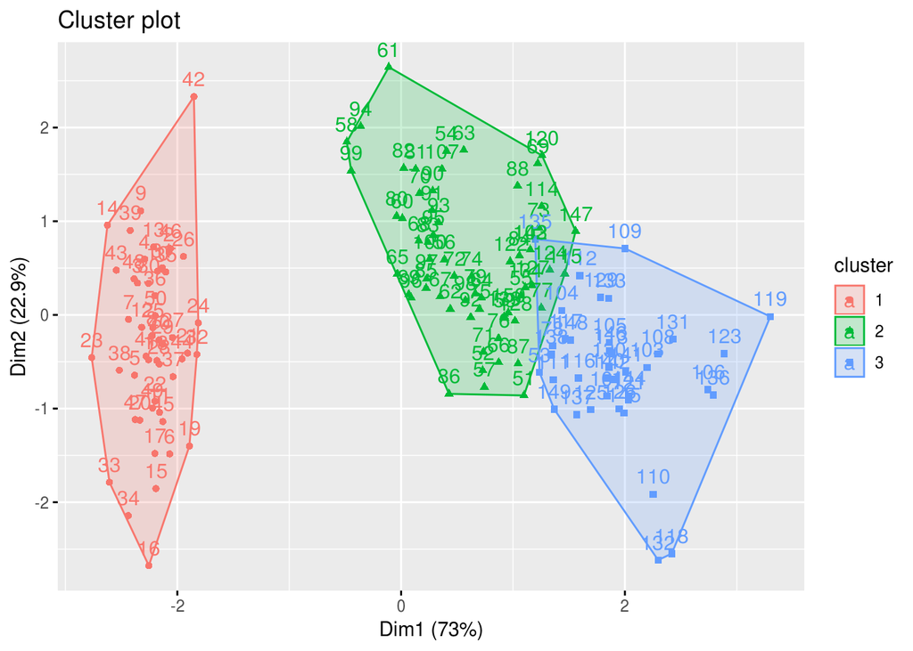

Jak widać na wizualizacjach, oba algorytmy dzielą na klastry w niemalże identyczny sposób.

# Centra klastrów

Centra klastrów możemy znaleźć w obiektach zwracanych przez funkcje `kmeans` i `pam`

## Porównanie dla dwóch klastrów

```
##   Sepal.Length Sepal.Width Petal.Length Petal.Width
## 1     5.005660    3.369811     1.560377    0.290566
## 2     6.301031    2.886598     4.958763    1.695876
```

```
##      Sepal.Length Sepal.Width Petal.Length Petal.Width
## [1,]          5.0         3.4          1.5         0.2
## [2,]          6.2         2.8          4.8         1.8
```

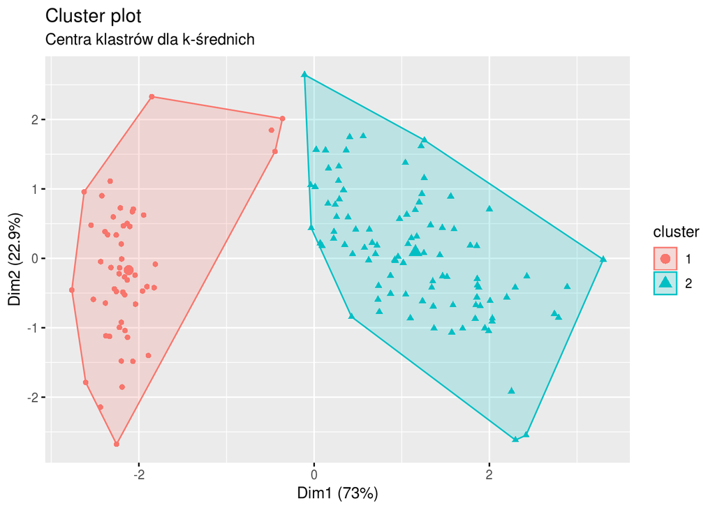

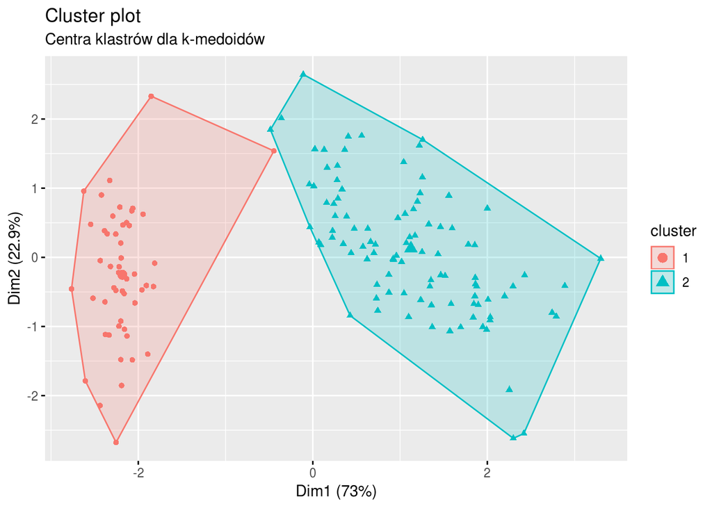

```
##   Sepal.Length Sepal.Width Petal.Length Petal.Width
## 1     5.901613    2.748387     4.393548    1.433871
## 2     5.006000    3.428000     1.462000    0.246000
## 3     6.850000    3.073684     5.742105    2.071053
```

```
##      Sepal.Length Sepal.Width Petal.Length Petal.Width
## [1,]          5.0         3.4          1.5         0.2
## [2,]          6.0         2.9          4.5         1.5
## [3,]          6.8         3.0          5.5         2.1
```

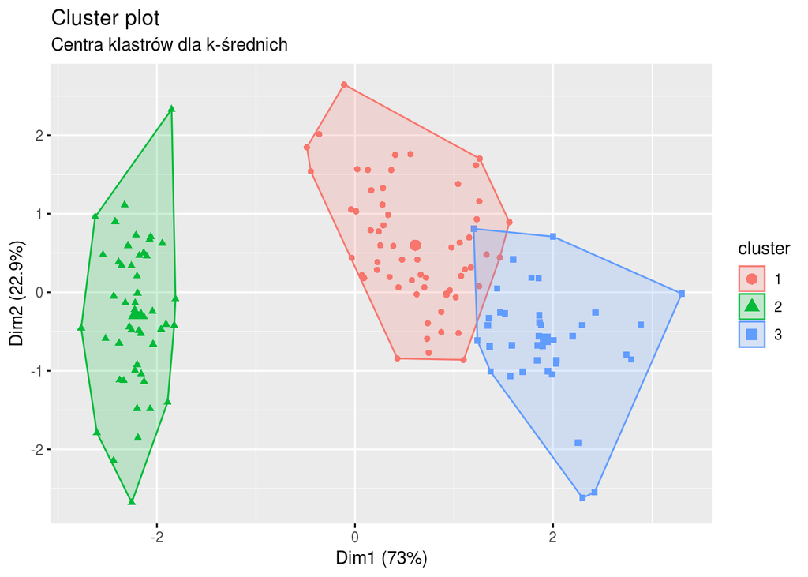

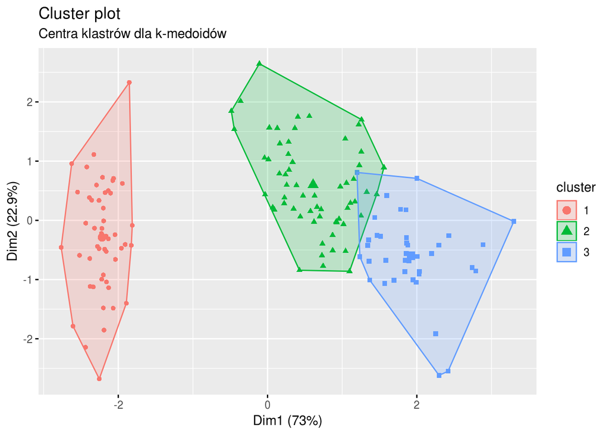

Również centra klastrów są w zbliżonych miejsach.

# Zbieżność

Implementacja metody k-medoidów, z której korzystam nie zwraca liczby iteracji, więc nie jestem w stanie zbadać i porównać szybkości zbieżności tych metod.